# Iconic - Data Science Challenge

Mickey Shi

28 November 2018

### Executive Report

The Data Science team has managed to develop a Deep Learning model that can predict customers’ gender (where unknown) with an accuracy of 97% based on their purchase information.

The model recognised certain variables to be the most important in predicting gender: 1. Proportion of items relating to Women Apparel 2. Proportion of items relating to Women Footwear 3. Proportion of Unisex items

The model is based on provided customer purchase data, although very extensive but required the following modifications to be fully useful (more derivation logics can be found in the “CLEAN” section of this report): - 249 records were found to be duplicate and were removed - The Days Since Last Order variable was corrected to contain day values - The Average Discount Rate variable was changed to percentage values - Corrected certain records with cancels and returns being greater than orders - Newsletter Subscriber indicator was changed to factor based variable - Coupon Discount variable had missing value and was imputed to 0

The data provided describes the absolute amount of orders, items, discounts and revenue. Further feature engineering included: - Percentiles and starndardised values which reflected information relative in the overall distribution for all customers in the data - Proportion of categorised items respective to overall purchase which reflected relative values of the same customer

Given there is no direct gender information provided, the classification of gender was inferred from the proportions of female and male items. The analysis of the distribution showed there to be a clear distinction in the proportions of gender specific item purchases, therefore a reasonable (and key) assumption would be to infer gender classes from the gender specific item variables.

Despite the already high accuracy of the model, there are still potential new variables which can improve the prediction accuracy, they include and are not limited to: - Known Gender: This can greatly reduce noise caused by the assumption of the derived gender class variable - Customer Names & Titles: Using text machine learning models to classify gender - Web Interactions: number of clicks, views, cart items can further enrich the user behaviour information - Contact/Support (Live Chat and Phone): Using NPL and text ML models to classify gender - Subscription Preferences: Can greatly improve visibility of gender specific preferences

The cost of getting these variables/models are to be weighted against the benefit of having additional accuracy in predicting gender to improve business sales.

### Background

Many of our customers at THE ICONIC - similar to most online shoppers - only provide the bare minimum of information needed when signing up as a new user or making a transaction on the site (i.e credit card details, delivery address etc). They do not provide their age, gender or any other personal details when they register as a new customer or they will simply purchase their items as a ‘Guest’ user.

Respecting customer privacy is of the utmost important at THE ICONIC and we understand why some shoppers are hesitant to provide personal information. However, to be able to better tailor our site, branding strategy, marketing, product and most importantly merchandising, we need to have a better handle on the profile of our shopper and understand the things that are more relevant to them.

What we have identified here is an opportunity to ‘infer’ a customer’s gender based on the amazingly rich user behavioural data, which will allow us to better tailor our site and offerings to their needs.

More information at https://github.com/theiconic/datascientist

Download files at: https://github.com/theiconic/datascientist/raw/master/test_data.db.zip https://github.com/theiconic/datascientist/raw/master/test_data.zip

Load Libraries & Set directory

```r
library(openssl)
library(sqldf)
library(dplyr)
library(jsonlite)
library(h2o)
setwd("C:/Users/Mickey Shi/Documents/Iconic Project/")
```

Follow instructions to unzip to directory

```r
#Generate password
raw_data_pw <- "welcometotheiconic"
sha256(raw_data_pw)
```

```
## [1] "186e48fa1aafbaf63c1c295e560c2a5e0bf241e9cae0a59038e27aa8225d8c63"
```

### Setup and Preparation

```r
#Read data base file into R
sqlite.driver <- dbDriver("SQLite")
db <- dbConnect(sqlite.driver, dbname = "test_data.db")
dbListTables(db)
```

```
## [1] "customers"
```

```r
customers_raw <- dbReadTable(db,"customers")
```

### Stage 1 : SQL

Unhash the sqlite database (test_data.db.zip) using the secret key provided by us, extract it. Write SQL queries to answer the following questions:

1.What was the total revenue to the nearest dollar for customers who have paid by credit card? Assumptions: - “revenue” is net of discounts and cancellations

```r
q1_ans <- sqldf("
                select round(sum(revenue),0) as cc_revenue
                from customers_raw
                where cc_payments > 0
                ")
q1_ans <- paste("$", prettyNum(q1_ans, big.mark = ","), sep="")
```

Answer: $50,372,282

2.What percentage of customers who have purchased female items have paid by credit card? Assume non multually exclusive for customers who pays by different payment methods

```r
q2_ans <- sqldf("
                select round(
                  cast(count(distinct (case when cc_payments > 0 then customer_id end)) as real)/
                  cast(count(distinct customer_id) as real),2)*100 as perc
                from customers_raw
                where female_items > 0
                ")
q2_ans <- paste(q2_ans, "%", sep="")
```

Answer: 65%

3.What was the average revenue for customers who used either iOS, Android or Desktop?

```r
q3_ans <- sqldf("
                select round(avg(revenue),2)
                from customers_raw
                where ios_orders > 0 or android_orders > 0 or desktop_orders > 0
                ")
q3_ans <- paste("$", prettyNum(q3_ans, big.mark = ","), sep="")
```

Answer: $1,484.89

4. We want to run an email campaign promoting a new mens luxury brand. Can you provide a list of customers we should send to?

```r
q4_ans <- sqldf("
                select customer_id
                from customers_raw
                where is_newsletter_subscriber = 'Y' and male_items > 0
                ")
write.csv(q4_ans, "email_campaign_list.csv")
```

Answer: See full list in file “email_campaign_list.csv”

Partial clean up

```r
rm(customers_raw)
```

### Stage 2 : CLEAN

Unhash the data (test_data.zip) using the secret key provided by us, extract it, most importantly clean it and put it in a form you can use - all programatically of course. We have also “intentionally” corrupted two columns in this file - two columns that might look correct but are not correct. They need “some correction” to be useful.

```r
raw_data <- read_json("data.json", simplifyVector = TRUE)

#Check and remove duplicates
check1 <- sum(duplicated(raw_data))
raw_data <- raw_data[!duplicated(raw_data),]

#Convert days_since_last_order variable from hours to days
raw_data$days_since_last_order <- raw_data$days_since_last_order/24

#Convert average_discount_used variable to percentage
raw_data$average_discount_used <- raw_data$average_discount_used/10000

#Fix formats
raw_data$is_newsletter_subscriber <- as.factor(raw_data$is_newsletter_subscriber)

#Impute coupon_discount_applied variable with 0
raw_data$coupon_discount_applied[is.na(raw_data$coupon_discount_applied)] <- 0

#Correct cancel/return orders to be less or equal to total orders
raw_data$cancels <- ifelse(raw_data$orders<raw_data$cancels,raw_data$orders,raw_data$cancels)
raw_data$returns <- ifelse(raw_data$orders<raw_data$returns,raw_data$orders,raw_data$returns)
```

Data Cleaning Summary:  
- Duplicates removed: 249  
- Changed days_since_last_order from hours to days  
- Changed average_discount_used to discount rate (between 0 and 1)  
- Changed format is_newsletter_subscriber variable to factor  
- Imputed coupon_discount_applied with 0 value

### Stage 3 : BUILD

Build a deep learning model (preferably) or any other model that suitably answers this question and predict the inferred gender using the features provided and deriving more featueres at your end. Remember, there is no gender flag, so you are flying blind here.

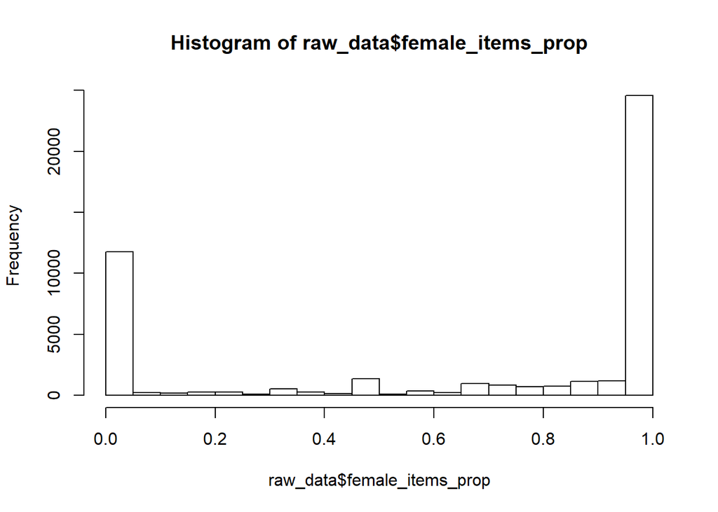

```r
#Derive additional variables

#Purchased orders
raw_data$purchases <- ifelse(raw_data$orders<raw_data$cancels,0,raw_data$orders - raw_data$cancels)

#Total purchase amount
raw_data$purchase_tot <- raw_data$revenue/(1-raw_data$average_discount_used)

#Average price per purchase
raw_data$avg_purchase_price <- raw_data$purchase_tot/raw_data$purchases

#cancellation rate
raw_data$cancel_rate <- ifelse(raw_data$cancels>raw_data$orders,0, raw_data$cancels/raw_data$orders)

#return rate
raw_data$return_rate <- ifelse(raw_data$returns>raw_data$orders,0, raw_data$returns/raw_data$orders)

#Derive proportions of items
raw_data$female_items_prop <- raw_data$female_items/raw_data$items
raw_data$male_items_prop <- raw_data$male_items/raw_data$items
raw_data$unisex_items_prop <- raw_data$unisex_items/raw_data$items
raw_data$wapp_items_prop <- raw_data$wapp_items/raw_data$items
raw_data$wftw_items_prop <- raw_data$wftw_items/raw_data$items
raw_data$mapp_items_prop <- raw_data$mapp_items/raw_data$items
raw_data$wacc_items_prop <- raw_data$wacc_items/raw_data$items
raw_data$macc_items_prop <- raw_data$macc_items/raw_data$items
raw_data$mftw_items_prop <- raw_data$mftw_items/raw_data$items
raw_data$wspt_items_prop <- raw_data$wspt_items/raw_data$items
raw_data$mspt_items_prop <- raw_data$mspt_items/raw_data$items
raw_data$curvy_items_prop <- raw_data$curvy_items/raw_data$items
raw_data$sacc_items_prop <- raw_data$sacc_items/raw_data$items
raw_data$msite_orders_prop <- raw_data$msite_orders/raw_data$orders
raw_data$desktop_orders_prop <- raw_data$desktop_orders/raw_data$orders
raw_data$android_orders_prop <- raw_data$android_orders/raw_data$orders
raw_data$ios_orders_prop <- raw_data$ios_orders/raw_data$orders
raw_data$other_device_orders_prop <- raw_data$other_device_orders/raw_data$orders
raw_data$work_orders_prop <- raw_data$work_orders/raw_data$orders
raw_data$home_orders_prop <- raw_data$home_orders/raw_data$orders
raw_data$parcelpoint_orders_prop <- raw_data$parcelpoint_orders/raw_data$orders
raw_data$other_collection_orders_prop <- raw_data$other_collection_orders/raw_data$orders

#calculate CDF values and standardised values
perc_vars <- c(
"days_since_first_order",
"days_since_last_order",
"orders",
"items",
"cancels",
"returns",
"different_addresses",
"shipping_addresses",
"devices",
"vouchers",
"cc_payments",
"paypal_payments",
"afterpay_payments",
"apple_payments",
"unisex_items",
"wapp_items",
"wftw_items",
"mapp_items",
"wacc_items",
"macc_items",
"mftw_items",
"wspt_items",
"mspt_items",
"curvy_items",
"sacc_items",
"msite_orders",
"desktop_orders",
"android_orders",
"ios_orders",
"other_device_orders",
"work_orders",
"home_orders",
"parcelpoint_orders",
"other_collection_orders",
"revenue"
  )

for (i in 1:length(perc_vars)) {
  cdf <- ecdf(raw_data[, which(names(raw_data) %in% perc_vars[i])])
  temp_vc <-cdf(raw_data[, which(names(raw_data) %in% perc_vars[i])])
  raw_data <- cbind(raw_data, temp_vc)
  colnames(raw_data)[which(colnames(raw_data)=="temp_vc")] <- paste0(perc_vars[i], "_perc")

  temp_vc <- scale(raw_data[, which(names(raw_data) %in% perc_vars[i])])
  raw_data <- cbind(raw_data, temp_vc)
  colnames(raw_data)[which(colnames(raw_data)=="temp_vc")] <- paste0(perc_vars[i], "_std")
}

#Analyse proportions of female and male related items
hist(raw_data$female_items_prop)
```

```r
#Model Assumption - The distribution of female items are quite definite in highlighting majority female or male item purchases. Therefore a fair assumption would be that "female_items" and "male_items" can provide a reasonable indication of the gender of the customers. More specifically, if more than 50% of the items are relation to female when the gender of the customer is assumped to be female.

#create model dataset
drop_vars <- c(
  "female_items",
  "male_items",
  "female_items_prop",
  "male_items_prop"
  )

gender_cutoff <- 0.5

#Derive Gender Class
gender_class <- ifelse(raw_data$female_items_prop>gender_cutoff, "female", "male")
model_data<- cbind(raw_data, gender_class)

model_data <- model_data[, -which(names(model_data) %in% drop_vars)]
```

#### Construct Deep Neural Net model

```r
h2o.init(nthreads=-1, max_mem_size="4G")
h2o.removeAll()

train_prop<-0.6
val_prop<-0.2

h2o_model_data <- as.h2o(model_data)

#Split train, validation and test data
splits <- h2o.splitFrame(h2o_model_data, c(train_prop,val_prop), seed=12345)
train_data  <- h2o.assign(splits[[1]], "train.hex")
val_data  <- h2o.assign(splits[[2]], "valid.hex")
test_data   <- h2o.assign(splits[[3]], "test.hex")

#Set response and predictors
response <- "gender_class"
predictors <- setdiff(names(train_data), response)


#Model 0 - Basic Neural Net
model0 <- h2o.deeplearning(
  model_id="model0",
  training_frame=train_data,
  validation_frame=val_data,
  x=predictors,
  y=response,
  hidden=c(200),
  epochs=1,
  variable_importances=T
)

#Model 1 - Deep Neural Net with hyper parameter tuning (random search)

hypertune_par <- list(
#Activation functions
  activation=c("Rectifier","Tanh","Maxout","RectifierWithDropout","TanhWithDropout","MaxoutWithDropout"),

#Hidden Layers
  hidden=list(c(100,100),c(200,200),c(100,100,100),c(100,100,100,100)),

#Dropout Ratio
  input_dropout_ratio=c(0,0.1),

#Regularizations
  l1=c(0,0.0005,0.001),
  l2=c(0,0.0005,0.001)
)

search_function <- list(strategy = "RandomDiscrete", max_models = 100, seed=12345, stopping_rounds=3, stopping_tolerance = 0.01)

dl_grid <- h2o.grid(
  training_frame=train_data,
  validation_frame=val_data,
  algorithm="deeplearning",
  x=predictors,
  y=response,
  epochs=1,
  stopping_metric="AUC",
  grid_id="dl_grid",
  score_duty_cycle=0.1,
  hyper_params=hypertune_par,
  search_criteria=search_function
)

model1_grid <- h2o.getGrid("dl_grid",sort_by="AUC",decreasing=TRUE)

model1<-h2o.getModel(model1_grid@model_ids[[1]])

#Inspect variable importance
model1_varimp <- head(as.data.frame(h2o.varimp(model1)),10)
```

Model Comparison

```r
h2o.performance(model0, test_data)
```

```
## H2OBinomialMetrics: deeplearning
##
## MSE:  0.03065834
## RMSE:  0.1750952
## LogLoss:  0.1228311
## Mean Per-Class Error:  0.03774101
## AUC:  0.9930745
## Gini:  0.9861489
##
## Confusion Matrix (vertical: actual; across: predicted) for F1-optimal threshold:
##        female male    Error       Rate
## female   5966  225 0.036343  =225/6191
## male      120 2946 0.039139  =120/3066
## Totals   6086 3171 0.037269  =345/9257
##
## Maximum Metrics: Maximum metrics at their respective thresholds
##                         metric threshold    value idx
## 1                       max f1  0.464548 0.944685 190
## 2                       max f2  0.095512 0.960520 298
## 3                 max f0point5  0.945018 0.951076  53
## 4                 max accuracy  0.780750 0.963379 123
## 5                max precision  0.999994 0.998543   0
## 6                   max recall  0.000006 1.000000 399
## 7              max specificity  0.999994 0.999515   0
## 8             max absolute_mcc  0.780750 0.917304 123
## 9   max min_per_class_accuracy  0.424987 0.962492 197
## 10 max mean_per_class_accuracy  0.341369 0.963101 218
##
## Gains/Lift Table: Extract with `h2o.gainsLift(<model>, <data>)` or `h2o.gainsLift(<model>, valid=<T/F>, xval=<T/F>)`
```

```r
h2o.performance(model1, test_data)
```

```
## H2OBinomialMetrics: deeplearning
##
## MSE:  0.02466369
## RMSE:  0.1570468
## LogLoss:  0.08102598
## Mean Per-Class Error:  0.0308746
## AUC:  0.9954217
## Gini:  0.9908435
##
## Confusion Matrix (vertical: actual; across: predicted) for F1-optimal threshold:
##        female male    Error       Rate
## female   5944  247 0.039897  =247/6191
## male       67 2999 0.021853   =67/3066
## Totals   6011 3246 0.033920  =314/9257
##
## Maximum Metrics: Maximum metrics at their respective thresholds
##                         metric threshold    value idx
## 1                       max f1  0.265126 0.950253 272
## 2                       max f2  0.100629 0.972133 316
## 3                 max f0point5  0.856293 0.959665  89
## 4                 max accuracy  0.265126 0.966080 272
## 5                max precision  0.999924 1.000000   0
## 6                   max recall  0.000320 1.000000 397
## 7              max specificity  0.999924 1.000000   0
## 8             max absolute_mcc  0.265126 0.925418 272
## 9   max min_per_class_accuracy  0.397114 0.964788 241
## 10 max mean_per_class_accuracy  0.100629 0.969827 316
##
## Gains/Lift Table: Extract with `h2o.gainsLift(<model>, <data>)` or `h2o.gainsLift(<model>, valid=<T/F>, xval=<T/F>)`
```

Top 10 important variables

|  | variable | relative_importance | scaled_importance | percentage |
| --- | --- | --- | --- | --- |
| 1 | wapp_items_prop | 1.0000000 | 1.0000000 | 0.014229862 |
| 2 | wftw_items_prop | 0.9691046 | 0.9691046 | 0.013790225 |
| 3 | unisex_items_prop | 0.9570085 | 0.9570085 | 0.013618099 |
| 4 | wacc_items_prop | 0.7197561 | 0.7197561 | 0.010242029 |
| 5 | mapp_items_prop | 0.7011220 | 0.7011220 | 0.009976870 |
| 6 | days_since_last_order_std | 0.6753539 | 0.6753539 | 0.009610193 |
| 7 | mftw_items_perc | 0.6738701 | 0.6738701 | 0.009589079 |
| 8 | wspt_items_prop | 0.6674592 | 0.6674592 | 0.009497852 |
| 9 | unisex_items_perc | 0.6622342 | 0.6622342 | 0.009423501 |
| 10 | is_newsletter_subscriber.Y | 0.6575192 | 0.6575192 | 0.009356407 |

#### Save best performing model

```r
h2o.saveModel(model1, path = "C:/Users/Mickey Shi/Documents/Iconic Project", force=TRUE)
```

```
## [1] "C:\\Users\\Mickey Shi\\Documents\\Iconic Project\\dl_grid_model_72"
```

### Stage 4 : DELIVER

Package all your process, findings and code into a reproducible document that can be understood by a business user. A repo of the code branch would be a great thing to have! This reproducible report* must answer the following questions:

1. How did you clean the data and what was wrong with it? Close to 90% of a Data Scientist’s job is in cleaning data
2. What are the features you used as-is and which one did you engineer using the given ones? What do they mean in the real world?
3. What does the output look like - how close is the accuracy of the prediction in light of data with labelled flags?
4. What other features and variables can you think of, that can make this process more robust? Can you make a recommendation of top 5 features you’d seek to find apart from the ones given here
5. Summarize your findings in an executive summary

All items answered in the body of the report